# Model assumptions

## Application of CLT

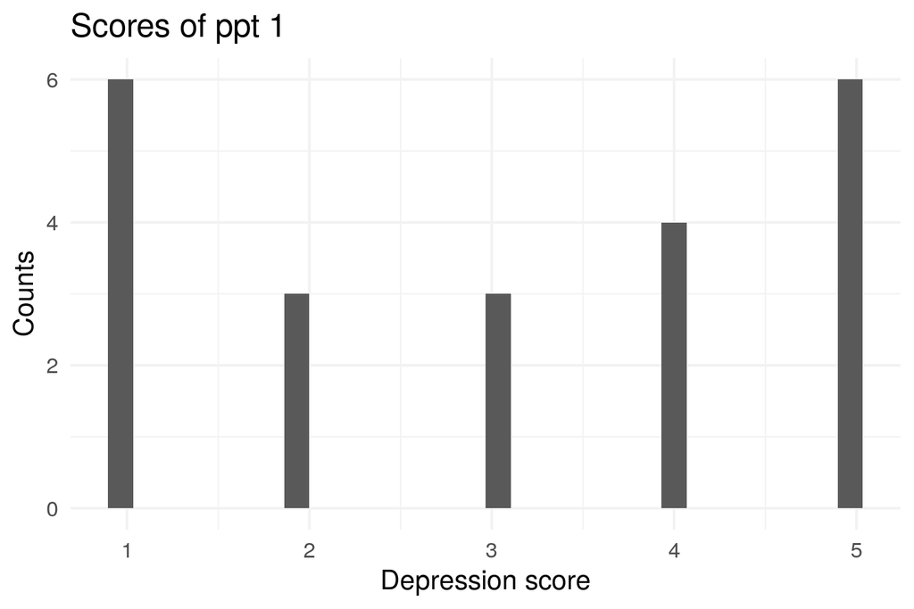

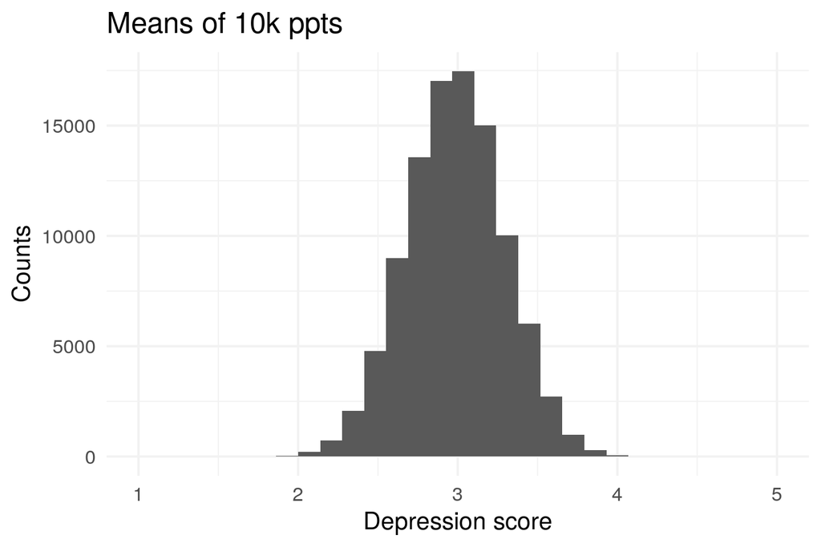

## Independent and identically distributed (iid)

## Independent and identically distributed (iid)

- Most fundamental assumptions for the CLT and therefore statistical tests
- Our observations are independent and identically distributed if each observation has the same distribution as the others and all observations are mutually independent.
- Related to how the data were obtained.

## Independent and identically distributed (iid)

### independence

- One observation must be unrelated from the next.
- Assessing the spread of COVID infections: sampled one person per house hold
- Depression example
  - 22 depression items with different questions
- Violations:
  - repeating the same questions
  - testing the same people multiple times
  - not randomising the presentation order

## Independent and identically distributed (iid)

### identical distribution

- Observations must come from the same distribution
- or family of distributions: e.g. normal, Poisson (discrete count data), binomial (binary data)
- Depression example: 22 items about depression, all 5-point Likert scale
- Violation:
  - you want to assess depression but some questions ask about coffee preferences
  - including one 6-point Likert scale amongst 5-point Likert scales
  - studying the effect of snapchat on selfesteem but also including twitter users without snapchat account
  - vs. studying the effect of social media on selfesteem

## Homogeneity of variance

## Homogeneity of variance

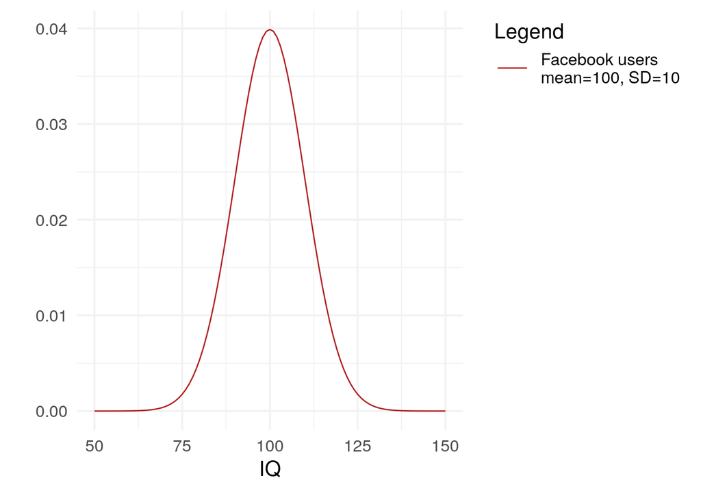

- Homogeneity = same
- Heterogeneity = different
- Equality of variances
- Variance = SD\(^2\): deviations between observations and their mean

## Homogeneity of variance

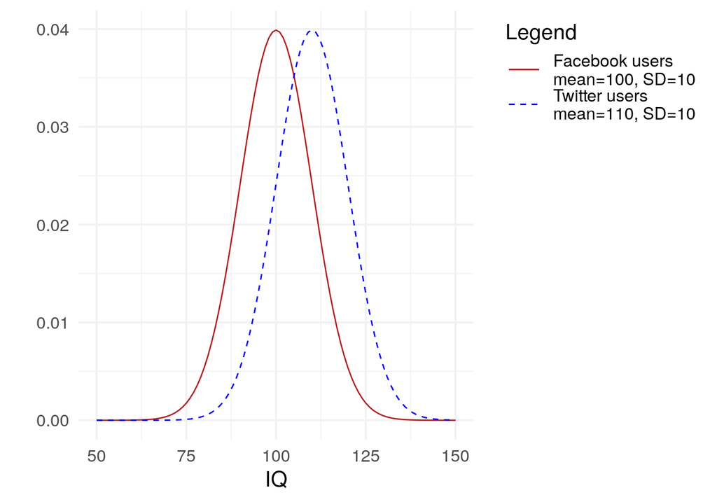

- Homogeneity = same
- Heterogeneity = different
- Equality of variances
- Variance: deviations between observations and their mean (=SD\(^2\))

## Homogeneity of variance

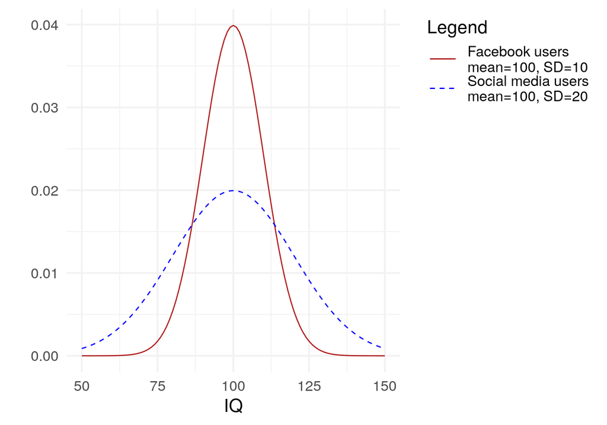

- Homogeneity = same
- Heterogeneity = different
- Equality of variances
- Variance = SD\(^2\): deviations between observations and their mean
- More diverse groups are more plausible to have a larger variance (even if the means are the same).
- Levene’s test

## Epilogue

## Summary

- Sample size matters!
- Allegedly Stephen Hawking said when asked about his IQ “People who boast about their IQ are losers.”

## Useful textbook resources

- Field, Miles, and Field (2012) Chapter 5
- Baguley (2012) Chapter 9
- Matloff (2019) Chapter 8 and 9 (also 7)
- Howitt and Cramer (2014) Chapter 5

## Outlook

- Model assumptions: workshop task
- Model evaluation: test assumptions
- Model violations: correction of violations

## References

Baguley, Thom. 2012. *Serious Stats: A Guide to Advanced Statistics for the Behavioral Sciences*. Macmillan International Higher Education.

Bürkner, Paul-Christian, and Matti Vuorre. 2019. “Ordinal Regression Models in Psychology: A Tutorial.” *Advances in Methods and Practices in Psychological Science* 2 (1): 77–101.

Field, Andy, Jeremy Miles, and Zoë Field. 2012. *Discovering Statistics Using R*. Sage publications.

Gill, Jeff. 2014. *Bayesian Methods: A Social and Behavioral Sciences Approach*. Vol. 20. CRC press.

Howitt, Dennis, and Duncan Cramer. 2014. *Introduction to Statistics in Psychology*. 6th ed. Pearson Education.

Liddell, Torrin M., and John K. Kruschke. 2018. “Analyzing Ordinal Data with Metric Models: What Could Possibly Go Wrong?” *Journal of Experimental Social Psychology* 79: 328–48.

Lynn, Richard, and Tatu Vanhanen. 2001. “National IQ and Economic Development: A Study of Eighty-One Nations.” *Mankind Quarterly* 41 (4): 415–35.

Matloff, Norman. 2019. *Probability and Statistics for Data Science: Math + R + data*. CRC Press.

Radloff, Lenore Sawyer. 1977. “The CES-D Scale: A Self-Report Depression Scale for Research in the General Population.” *Applied Psychological Measurement* 1 (3): 385–401.

Robinson, Mark A. 2018. “Using Multi-Item Psychometric Scales for Research and Practice in Human Resource Management.” *Human Resource Management* 57 (3): 739–50.